# IODS course project

Abushahba

# About the project

This seems very interesting course, I am much excited day after day about its potentials and applications!

My Github repository is [*here*](https://github.com/Abushahba/IODS-project.git)

# Regression and model validation

Here we practice Data management and wrangling as well as linear Regression model creation and analysis.

Our data set from Data wrangling will be used, R script for Data wrangling can be found [*here*](https://github.com/Abushahba/IODS-project/blob/master/data/create_learning2014.R)

## Reading students2014 data, Explore the structure and the dimensions of the data

```r
read.csv (file = "C:/Users/ahmed/Desktop/IODS-project/data/learning2014_AGA.csv")
```

```
##       X gender Age Attitude     deep  stra     surf Points
## 1     1      F  53       37 3.583333 3.375 2.583333     25
## 2     2      M  55       31 2.916667 2.750 3.166667     12
## 3     3      F  49       25 3.500000 3.625 2.250000     24
## 4     4      M  53       35 3.500000 3.125 2.250000     10
## 5     5      M  49       37 3.666667 3.625 2.833333     22
## 6     6      F  38       38 4.750000 3.625 2.416667     21
## 7     7      M  50       35 3.833333 2.250 1.916667     21
## 8     8      F  37       29 3.250000 4.000 2.833333     31
## 9     9      M  37       38 4.333333 4.250 2.166667     24
## 10   10      F  42       21 4.000000 3.500 3.000000     26
## 11   11      M  37       39 3.583333 3.625 2.666667     31
## 12   12      F  34       38 3.833333 4.750 2.416667     31
## 13   13      F  34       24 4.250000 3.625 2.250000     23
## 14   14      F  34       30 3.333333 3.500 2.750000     25
```

[output cut: 152 more lines]

let’s make it in “lrn2014_AGA”

```r
lrn2014_AGA <- read.csv (file = "C:/Users/ahmed/Desktop/IODS-project/data/learning2014_AGA.csv")

str(lrn2014_AGA)
```

```
## 'data.frame':    166 obs. of  8 variables:
##  $ X       : int  1 2 3 4 5 6 7 8 9 10 ...
##  $ gender  : Factor w/ 2 levels "F","M": 1 2 1 2 2 1 2 1 2 1 ...
##  $ Age     : int  53 55 49 53 49 38 50 37 37 42 ...
##  $ Attitude: int  37 31 25 35 37 38 35 29 38 21 ...
##  $ deep    : num  3.58 2.92 3.5 3.5 3.67 ...
##  $ stra    : num  3.38 2.75 3.62 3.12 3.62 ...
##  $ surf    : num  2.58 3.17 2.25 2.25 2.83 ...
##  $ Points  : int  25 12 24 10 22 21 21 31 24 26 ...
```

```r
dim(lrn2014_AGA)
```

```
## [1] 166   8
```

structure shows that we have data frame of 166 observations about 8 variables describing students’ performance.

## Graphical overview of the data

now let’s have a graphical overview of the data, can we access ggplot2 and GGally library? NO! we need to install package first!

[figure not shown]

```r
library(ggplot2)

library(GGally)

plot <- ggpairs(lrn2014_AGA, mapping = aes(col = gender, alpha = 0.3), lower = list(combo = wrap("facethist", bins = 20)))

plot
```

looking onto our plots we can have an idea about normality of distribution, different variables correlation, Our sample included more females almost double males, We can see for example that Age is more correlated with strategic thinking, then with Attitude and deep thinking almost similarily, while it is not correlated Points and superficial thinking.The attitude is relatively highly correlated with the Points earned, however, it’s also correlated to deep thinking more than with strategic thinking. Deep thinking is somehow correlated with strategic thinking.Strategic thinking has somthing to do with Points Whereas superficial thinking is not correlated with Points.

```r
summary(lrn2014_AGA)
```

```
##        X          gender       Age           Attitude          deep
##  Min.   :  1.00   F:110   Min.   :17.00   Min.   :14.00   Min.   :1.583
##  1st Qu.: 42.25   M: 56   1st Qu.:21.00   1st Qu.:26.00   1st Qu.:3.333
##  Median : 83.50           Median :22.00   Median :32.00   Median :3.667
##  Mean   : 83.50           Mean   :25.51   Mean   :31.43   Mean   :3.680
##  3rd Qu.:124.75           3rd Qu.:27.00   3rd Qu.:37.00   3rd Qu.:4.083
##  Max.   :166.00           Max.   :55.00   Max.   :50.00   Max.   :4.917
##       stra            surf           Points
##  Min.   :1.250   Min.   :1.583   Min.   : 7.00
##  1st Qu.:2.625   1st Qu.:2.417   1st Qu.:19.00
##  Median :3.188   Median :2.833   Median :23.00
##  Mean   :3.121   Mean   :2.787   Mean   :22.72
##  3rd Qu.:3.625   3rd Qu.:3.167   3rd Qu.:27.75
##  Max.   :5.000   Max.   :4.333   Max.   :33.00
```

## Regression Model fitting

Now let’s hypthesize a model to test how Attitude, deep and strategic thinking affect student’s exam points

```r
fit <- lm(Points ~ Attitude + deep + stra, data = lrn2014_AGA)

summary(fit)
```

```
##
## Call:
## lm(formula = Points ~ Attitude + deep + stra, data = lrn2014_AGA)
##
## Residuals:
##      Min       1Q   Median       3Q      Max
## -17.5239  -3.4276   0.5474   3.8220  11.5112
##
## Coefficients:
##             Estimate Std. Error t value Pr(>|t|)
## (Intercept) 11.39145    3.40775   3.343  0.00103 **
## Attitude     0.35254    0.05683   6.203 4.44e-09 ***
## deep        -0.74920    0.75066  -0.998  0.31974
## stra         0.96208    0.53668   1.793  0.07489 .
## ---
## Signif. codes:  0 '***' 0.001 '**' 0.01 '*' 0.05 '.' 0.1 ' ' 1
##
## Residual standard error: 5.289 on 162 degrees of freedom
## Multiple R-squared:  0.2097, Adjusted R-squared:  0.195
## F-statistic: 14.33 on 3 and 162 DF,  p-value: 2.521e-08
```

Summary showing in the coefficients section that there is higher probability that deep thinking values are wrong, so it should be rejected from our model.Now let’s return back to our fit model and try to refine by backwards elimination

```r
fit <- lm(Points ~ Attitude + stra, data = lrn2014_AGA)

summary(fit)
```

```
##
## Call:
## lm(formula = Points ~ Attitude + stra, data = lrn2014_AGA)
##
## Residuals:
##      Min       1Q   Median       3Q      Max
## -17.6436  -3.3113   0.5575   3.7928  10.9295
##
## Coefficients:
##             Estimate Std. Error t value Pr(>|t|)
## (Intercept)  8.97290    2.39591   3.745  0.00025 ***
## Attitude     0.34658    0.05652   6.132 6.31e-09 ***
## stra         0.91365    0.53447   1.709  0.08927 .
## ---
## Signif. codes:  0 '***' 0.001 '**' 0.01 '*' 0.05 '.' 0.1 ' ' 1
##
## Residual standard error: 5.289 on 163 degrees of freedom
## Multiple R-squared:  0.2048, Adjusted R-squared:  0.1951
## F-statistic: 20.99 on 2 and 163 DF,  p-value: 7.734e-09
```

I am still not convinced to keep strategic thinking, let’s trim it!

```r
fit <- lm(Points ~ Attitude , data = lrn2014_AGA)

summary(fit)
```

```
##
## Call:
## lm(formula = Points ~ Attitude, data = lrn2014_AGA)
##
## Residuals:
##      Min       1Q   Median       3Q      Max
## -16.9763  -3.2119   0.4339   4.1534  10.6645
##
## Coefficients:
##             Estimate Std. Error t value Pr(>|t|)
## (Intercept) 11.63715    1.83035   6.358 1.95e-09 ***
## Attitude     0.35255    0.05674   6.214 4.12e-09 ***
## ---
## Signif. codes:  0 '***' 0.001 '**' 0.01 '*' 0.05 '.' 0.1 ' ' 1
##
## Residual standard error: 5.32 on 164 degrees of freedom
## Multiple R-squared:  0.1906, Adjusted R-squared:  0.1856
## F-statistic: 38.61 on 1 and 164 DF,  p-value: 4.119e-09
```

According to this we can conclude that there is some statistical relationship between Student attitude and his exam points. what about the low R-squared? is it always bad? please see: http://blog.minitab.com/blog/adventures-in-statistics-2/regression-analysis-how-do-i-interpret-r-squared-and-assess-the-goodness-of-fit

## Model Analysis

let’s have alook on the distribution and variability of the data around the regression line using some diagnostic plots

[figure not shown]

[figure not shown]

[figure not shown]

```r
plot(fit, which = c(1, 2, 5))
```

The low R-squared graph shows that even noisy, high-variability data can have a significant trend.The trend indicates that the predictor variable still provides information about the response even though data points fall further from the regression line.

we assume that errors are normally distributed, right? well look at the QQ-plot you will find that most of the points fit to the underlying line (more or less), so our assumption of normal distribution for the errors is ok! next plot shows how the residuals are reasonably random spread around our model, which is good hopefully, as it tells that size of errors shold not depend on explanatory variables. Final plot; residuals vs. leverage, showing that although we have some outliers but they are more or less equally distributed exerting regular leverage, that I feel that we don’t need to worry about!

# Logistic regression

Here we will practice some priciples of **logistic regression** using the joined student alcohol consumption data, let’s have a look on that

```r
analys3 <-read.csv("C:/Users/ahmed/Desktop/IODS-project/data/joined data set for analysis.csv")

glimpse(analys3)
```

```
## Observations: 382
## Variables: 36
## $ X          <int> 1, 2, 3, 4, 5, 6, 7, 8, 9, 10, 11, 12, 13, 14, 15, ...
## $ ï..school  <fctr> GP, GP, GP, GP, GP, GP, GP, GP, GP, GP, GP, GP, GP...
## $ sex        <fctr> F, F, F, F, F, M, M, F, M, M, F, F, M, M, M, F, F,...
## $ age        <int> 18, 17, 15, 15, 16, 16, 16, 17, 15, 15, 15, 15, 15,...
## $ address    <fctr> U, U, U, U, U, U, U, U, U, U, U, U, U, U, U, U, U,...
## $ famsize    <fctr> GT3, GT3, LE3, GT3, GT3, LE3, LE3, GT3, LE3, GT3, ...
## $ Pstatus    <fctr> A, T, T, T, T, T, T, A, A, T, T, T, T, T, A, T, T,...
## $ Medu       <int> 4, 1, 1, 4, 3, 4, 2, 4, 3, 3, 4, 2, 4, 4, 2, 4, 4, ...
## $ Fedu       <int> 4, 1, 1, 2, 3, 3, 2, 4, 2, 4, 4, 1, 4, 3, 2, 4, 4, ...
## $ Mjob       <fctr> at_home, at_home, at_home, health, other, services...
## $ Fjob       <fctr> teacher, other, other, services, other, other, oth...
## $ reason     <fctr> course, course, other, home, home, reputation, hom...
## $ nursery    <fctr> yes, no, yes, yes, yes, yes, yes, yes, yes, yes, y...
```

[output cut: 23 more lines]

This data approach student achievement in secondary education of two Portuguese schools. The data (in the two sets) attributes include student grades, demographic, social and school related features and it was collected by using school reports and questionnaires, more details can be found [*here*](https://archive.ics.uci.edu/ml/datasets/Student+Performance), I have performed some data wrangling to Keep only the students present in both data sets, combine the ‘duplicated’ answers in the joined data, take the average of the answers related to weekday and weekend alcohol consumption and create a new logical column ‘high_use’ which is TRUE for students for which ‘alc_use’ is greater than 2 (and FALSE otherwise), and the Rscript for that can be found [*here*](https://github.com/Abushahba/IODS-project/blob/master/data/create_alc.R)

## The purpose

The purpose of analysis is to study the relationships between high/low alcohol consumption and some of the other variables in the data. To do this, we choose 4 interesting variables in the data; absences,quality of family relationship, sex (M) and free time after school. We hypthesize that those factors are correlated with higher alchol consumption.

Let’s have a look on that:

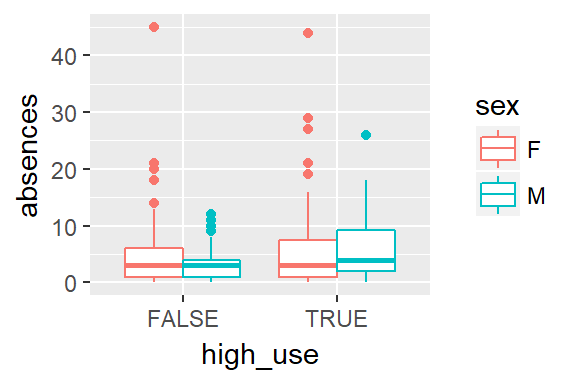

```r
g1 <- ggplot(analys3, aes(x = high_use, y = absences, col = sex))

g1 + geom_boxplot()
```

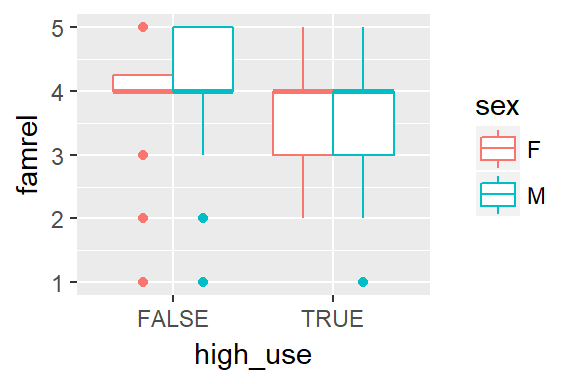

```r
g2 <- ggplot(analys3, aes(x = high_use, y = famrel, col = sex))

g2 + geom_boxplot()
```

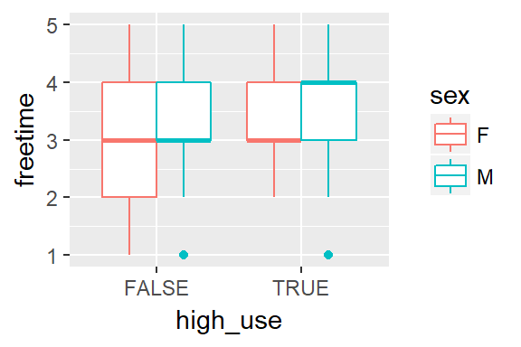

```r
g3 <- ggplot(analys3, aes(x = high_use, y = freetime, col = sex))

g3 + geom_boxplot()
```

```r
analys3 %>% group_by(sex, absences, famrel, high_use) %>% summarise(count = n(), mean_freetime = mean(freetime))
```

```
## # A tibble: 149 x 6
## # Groups:   sex, absences, famrel [?]
##       sex absences famrel high_use count mean_freetime
##    <fctr>    <int>  <int>    <lgl> <int>         <dbl>
##  1      F        0      3    FALSE     2      2.500000
##  2      F        0      3     TRUE     3      3.333333
##  3      F        0      4    FALSE    15      2.933333
##  4      F        0      4     TRUE     2      3.500000
##  5      F        0      5    FALSE    11      2.636364
##  6      F        0      5     TRUE     1      4.000000
##  7      F        1      1    FALSE     1      2.000000
##  8      F        1      2    FALSE     1      3.000000
##  9      F        1      2     TRUE     1      3.000000
## 10      F        1      3    FALSE     6      3.000000
## # ... with 139 more rows
```

## Fitting a model

To statistically test this lets fit logistic regression to explore the relationship between our chosen variables and the binary high/low alcohol consumption variable as the target variable.

```r
m <- glm(high_use ~ absences + sex + famrel + freetime, data = analys3, family = "binomial")

summary(m)
```

```
##
## Call:
## glm(formula = high_use ~ absences + sex + famrel + freetime,
##     family = "binomial", data = analys3)
##
## Deviance Residuals:
##     Min       1Q   Median       3Q      Max
## -1.9125  -0.8195  -0.5923   1.0419   2.0860
##
## Coefficients:
##             Estimate Std. Error z value Pr(>|z|)
## (Intercept) -1.56113    0.62549  -2.496 0.012565 *
## absences     0.09488    0.02244   4.229 2.35e-05 ***
## sexM         0.92271    0.24859   3.712 0.000206 ***
## famrel      -0.34855    0.13181  -2.644 0.008187 **
## freetime     0.33967    0.12673   2.680 0.007358 **
## ---
## Signif. codes:  0 '***' 0.001 '**' 0.01 '*' 0.05 '.' 0.1 ' ' 1
##
## (Dispersion parameter for binomial family taken to be 1)
##
##     Null deviance: 465.68  on 381  degrees of freedom
## Residual deviance: 417.44  on 377  degrees of freedom
## AIC: 427.44
##
## Number of Fisher Scoring iterations: 4
```

so, in the summary of our model we can taste the close correlation between absences, sex variables and higher use of alchol, and less correlation yet present between status of family relatoiship and freetime with higher alchol consumption.

let’s print out the coefficients of the model to use to obtain Odds ratio (OR) and then confidence intervals (CI)

```r
coef(m)
```

```
## (Intercept)    absences        sexM      famrel    freetime
## -1.56112511  0.09487753  0.92270514 -0.34854597  0.33967147
```

```r
OR <- coef(m) %>% exp()

CI <- confint(m) %>% exp()
cbind(OR, CI)
```

```
##                    OR     2.5 %    97.5 %
## (Intercept) 0.2098998 0.0600191 0.7022687
## absences    1.0995242 1.0542744 1.1516588
## sexM        2.5160876 1.5542543 4.1270709
## famrel      0.7057135 0.5433500 0.9127012
## freetime    1.4044861 1.0989755 1.8082673
```

## Exploring the predictive power of our model

```r
m <- glm(high_use ~ freetime + absences + sex, data = analys3, family = "binomial")

probabilities <- predict(m, type = "response")

analys3 <- mutate(analys3, probability = probabilities)

analys3 <- mutate(analys3, prediction = (probability > 0.5))

select(analys3, freetime, absences, sex, high_use, probability, prediction) %>% tail(10)
```

```
##     freetime absences sex high_use probability prediction
## 373        3        0   M    FALSE   0.2696155      FALSE
## 374        4        7   M     TRUE   0.4945212      FALSE
## 375        3        1   F    FALSE   0.1449414      FALSE
## 376        4        6   F    FALSE   0.2697703      FALSE
## 377        4        2   F    FALSE   0.1998871      FALSE
## 378        3        2   F    FALSE   0.1574882      FALSE
## 379        2        2   F    FALSE   0.1227034      FALSE
## 380        1        3   F    FALSE   0.1034644      FALSE
## 381        4        4   M     TRUE   0.4218155      FALSE
## 382        4        2   M     TRUE   0.3749754      FALSE
```

```r
table(high_use = analys3$high_use, prediction = analys3$prediction) %>% prop.table() %>% addmargins()
```

```
##         prediction
## high_use      FALSE       TRUE        Sum
##    FALSE 0.66492147 0.03664921 0.70157068
##    TRUE  0.23036649 0.06806283 0.29842932
##    Sum   0.89528796 0.10471204 1.00000000
```

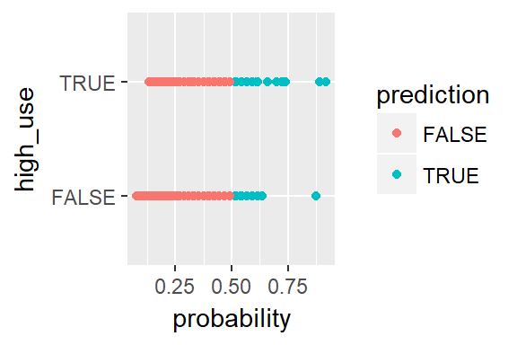

```r
g <- ggplot(analys3, aes(x = probability, y = high_use, col = prediction))

g + geom_point()
```

It is evident that our prediction is not sensitive enough to predict higher alchol consumption; however, it was relatively specific in prdicting lower alchol consumers.

Now, let’s compute the total proportion of inaccurately classified individuals

```r
loss_func <- function(class, prob) {
  n_wrong <- abs(class - prob) > 0.5
  mean(n_wrong)
}

loss_func(class = analys3$high_use, prob = analys3$probability)
```

```
## [1] 0.2670157
```

so, in our model the mean of incorrectly classified observations is around 0.267

## Cross validation

Performing 10-fold cross-validation on our model, compute the average number of wrong predictions in the (training) data, compare to average number of wrong predictions in the cross validation

```r
loss_func <- function(class, prob) {
  n_wrong <- abs(class - prob) > 0.5
  mean(n_wrong)
}

loss_func(class = analys3$high_use, prob = analys3$probability)
```

```
## [1] 0.2670157
```

```r
library(boot)
cv <- cv.glm(data = analys3, cost = loss_func, glmfit = m, K = 10)

cv$delta[1]
```

```
## [1] 0.2670157
```